# Downstream Analysis Notebook - Tabula muris version

Tabula Muris P8_15 trachea

Dídac Jiménez

23-03-2023

## Purpose

The purpose of this notebook is to analyze the already preprocessed data provided by Tabula Muris as `.robj` and obtain:

- Number of cells, genes and molecules, before and after filtering.
- A graphic of the clusters on a t-SNE dimensionality reduction image.
- A file detailing the top 10 differentially expressed genes of each cluster.
- A file detailing the cluster of each cell.

I can then use these results to compare them with those obtained with the scRNA-seq count matrix obtained from the data I preprocessed.

## Preparation and setup

### Point to files and directories

Before I start with the analysis I save the path where I want to save the result files listed above. I also save to a variable the path to the `extid2description.csv` file, which is relevant later. To reproduce the results *set the working directory to the repository* and the *knit directory to the working directory* and nothing from this chunk needs to be changed.

```r
extid2descriptionpath <- "./Refs/extid2description.csv"
output_path <- "./Refs/"
```

### Load .robj into seurat object

Another preparatory step is to load the Tabula Muris data, provided as `.robj`. *To reproduce the results it is necessary to indicate the path to the `.robj` as it is not provided in the repository*. These files [are available in the Tabula Muris website](https://figshare.com/articles/dataset/Robject_files_for_tissues_processed_by_Seurat/5821263) and provide the counts matrix as well as other data in an expressionSet-like object from the `Seurat` package. However, the objects are from an outdated version of the library (V2) so it has to be updated (to V3).

Together with loading the object *it is also important to detail which set of cells we want to analyze*. Tabula muris provides the processed data from all cells from a given tissue in the same file, but more than one set of cells from the same tissue were studied and the raw data is provided separately. To find out which datasets are present in the object, run the next chunk and afterwards `unique(seurat.obj$channel)` and then type it in “dataset” with a “_” afterwards.

```r
dataset <- "10X_P8_15_"
load("~/Work/Datasets/Mouse/Robjects/droplet_Trachea_seurat_tiss.Robj")
seurat.obj <- UpdateSeuratObject(tiss)
```

```
## Updating from v2.X to v3.X
```

```
## Validating object structure
```

```
## Updating object slots
```

```
## Ensuring keys are in the proper structure
```

```
## Ensuring feature names don't have underscores or pipes
```

```
## Object representation is consistent with the most current Seurat version
```

```r
rm(tiss)
```

In the next chunk only the cells in the dataset of interest are kept.

```r
seurat.obj <- seurat.obj[,grep(dataset, colnames(seurat.obj))]
```

## Quality Control

### Data exploration

The first step of the downstream analysis is the quality control, which consists in manually filtering cells above or under some threshholds. Before filtering, however, I check how many cells, genes and molecules are present in the dataset which are relevant metrics for preprocessing. It is important to note that the datasets provided by TabulaMuris are already filtered even though I will filter them further

```r
sum(seurat.obj$nCount_RNA)
```

```
## [1] 22334002
```

```r
length(colnames(seurat.obj))
```

```
## [1] 4643
```

```r
length(rownames(seurat.obj))
```

```
## [1] 23341
```

This Tabula Muris dataset has a total of 23341 genes expressed across 4643 cells, totalling 2.2334002^{7} RNA molecules.

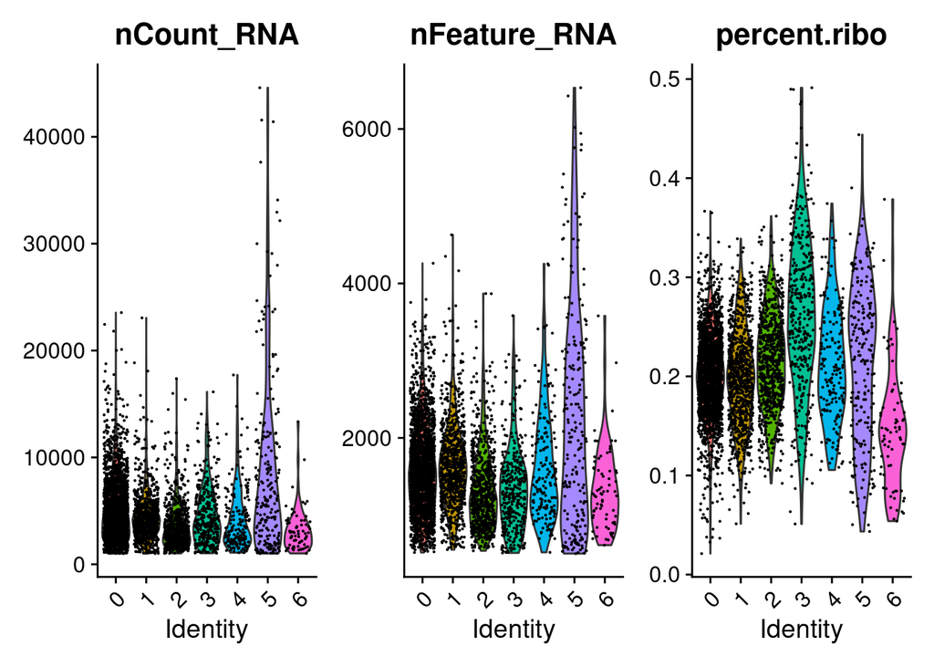

```r
VlnPlot(seurat.obj, features = c("nCount_RNA", "nFeature_RNA","percent.ribo"), ncol = 3)
```

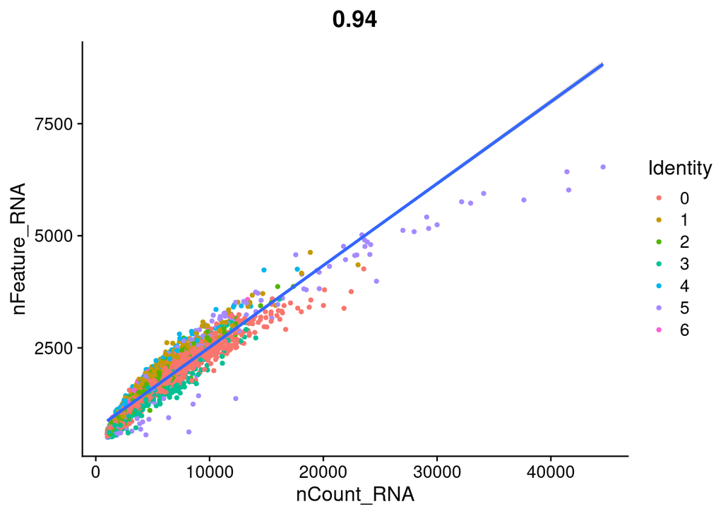

```r
FeatureScatter(seurat.obj, feature1 = "nCount_RNA", feature2 = "nFeature_RNA")+geom_smooth(method='lm')
```

The data is separated into clusters previously computed by Tabula Muris but I will make the clusterization afterwards as well to have control over the process.

### Filtering

To filter the cells I set a limit visually, looking at the violin plots, on:

*Mitochondrial percentage: An upper limit, high values may indicate a broken nucleus, thus a compromised cell. For this notebook this is currently a work in progress.* Number of molecules: An upper limit, very high values may indicate the droplet contained two cells *Number of features: A lower limit, droplets with too few features may only contain environmental RNA

*These filters depend on each dataset and should be changed on each execution.* Set the lower and upper limits manually.

```r
nCount_threshold <- c(500, 10000)  # subset. Minimum and maximum number of molecules detected in a cell to be kept
nFeature_threshold <- c(300, 2200) # subset. Minimum and maximum number of features detected in a cell to be kept
percent.ribo_threshold <-5 # subset. Maximum percentage of mitocondrial molecules
```

To apply the filters `Seurat` provides a method for the `subset` function, and I save it in a different object so that I can run the chunks above again to compare and fine tune the filters.

```r
seurat.obj.filtered <-
  subset(
    x = seurat.obj,
    subset = nFeature_RNA > nFeature_threshold[1] &
      nFeature_RNA <  nFeature_threshold[2] &
      nCount_RNA >  nCount_threshold[1] &
      nCount_RNA < nCount_threshold[2] &
      percent.ribo < percent.ribo_threshold
  )
```

Next I show the plots again to check the filtering:

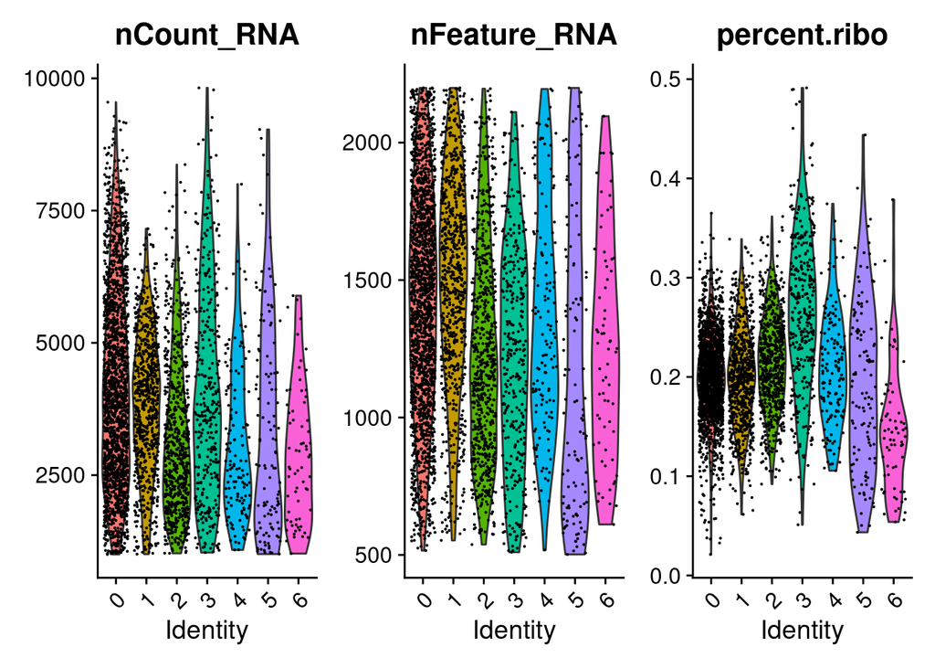

```r
VlnPlot(
  seurat.obj.filtered,
  features = c("nCount_RNA", "nFeature_RNA", "percent.ribo"),
  ncol = 3
)
```

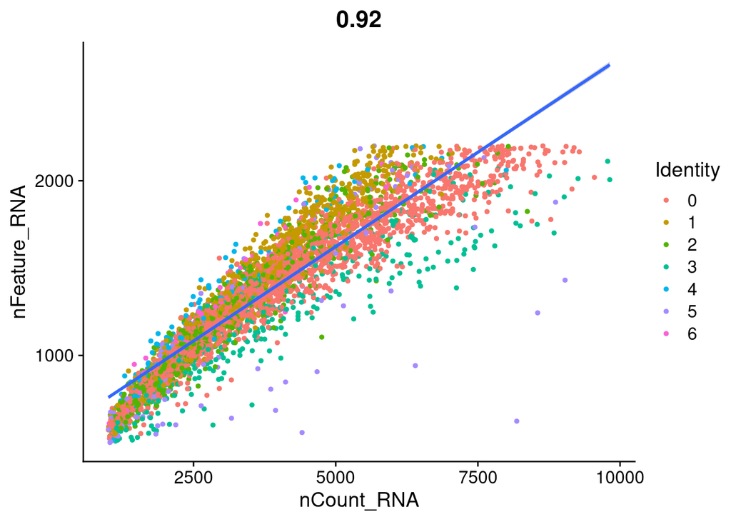

```r
FeatureScatter(seurat.obj.filtered,
               feature1 = "nCount_RNA",
               feature2 = "nFeature_RNA") + geom_smooth(method = 'lm')
```

```r
sum(seurat.obj.filtered$nCount_RNA)
```

```
## [1] 15480495
```

```r
length(colnames(seurat.obj.filtered))
```

```
## [1] 4008
```

```r
length(rownames(seurat.obj.filtered))
```

```
## [1] 23341
```

After filtering we keep a total of 23341 genes expressed across 4008 cells, totalling 1.5480495^{7} RNA molecules.

## Normalization, feature selection and scaling

### Normalization

To start this section I apply normalization to the expression values cells can be compared. Each value is divided by the total expression in its cell, multiplied by a scale factor and then log transformed.

$$N_{ij}=log(1+M\frac{A_{ij}}{\sum_{j'}A_{ij'}}) \\
M=10⁴$$

```r
seurat.obj.filtered<-NormalizeData(object=seurat.obj.filtered)
```

### Highly variable features

```r
seurat.obj.filtered <-
  FindVariableFeatures(
    object = seurat.obj.filtered,
    mean.cutoff = c(0.5, Inf),
    dispersion.cutoff = c(0.1, Inf)
  )
```

### Scale data

Through `ScaleData()` I shift the expression of each gene, so that the mean expression across cells is 0 and scales the expression of each gene, so that the variance across cells is 1. This step gives equal weight in downstream analyses, so that highly-expressed genes do not dominate and is a required step prior to dimensional reduction techniques.

$$X{ij}=(N_{ij}-\mu_i)/\sigma_i$$

```r
seurat.obj.filtered <-
  ScaleData(seurat.obj.filtered,
            vars.to.regress = c("nCount_RNA",  "percent.ribo"))
```

## Dimension reduction

### Principal Component Analysis

I run the analysis with `RunPCA()` over the selected most variable genes and then project the dimensional reduction (with `ProjectDim`) onto the entire dataset so that all genes have loadings.

```r
seurat.obj.filtered <-
  RunPCA(
    seurat.obj.filtered,
    features = VariableFeatures(seurat.obj.filtered),
    ndims.print = 1
  )
seurat.obj.filtered <- ProjectDim(seurat.obj.filtered, verbose = F)
```

After PCA, to keep enough PC’s to capture most of the variation I check the standard deviation of each PC and I keep those before the Elbow that appears in the plot. The PC kept will be used for clustering and t-SNE.

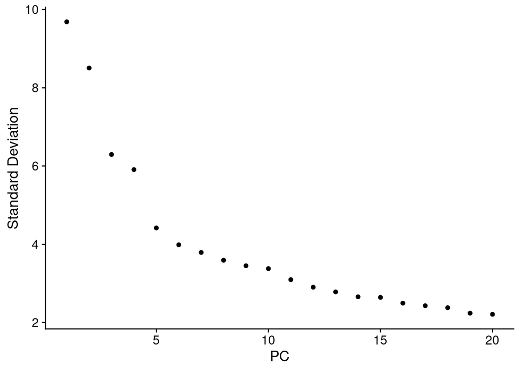

```r
ElbowPlot(seurat.obj.filtered)
```

*Chose in the next chunk the number of PC to be kept*

```r
n.pcs <- 6
```

### Shared Nearest Neighbor Clustering

To obtain the cluster, first, I compute the 30 nearest neighbors according in the dimensional space set by the selected PC with `FindNeighbours`. Then the clusters are identified through shared nearest neighbors with `FindClusters` and finally ploted through `DimPlot`.

```r
seurat.obj.filtered <-
  FindNeighbors(seurat.obj.filtered,
                dims = 1:n.pcs,
                k.param = 30)
seurat.obj.filtered <-
  FindClusters(
    seurat.obj.filtered,
    resolution = 0.1,
    random.seed = 42,
    n.start = 20,
    n.iter = 20
  )
```

```
## Modularity Optimizer version 1.3.0 by Ludo Waltman and Nees Jan van Eck
##
## Number of nodes: 4008
## Number of edges: 190842
##
## Running Louvain algorithm...
## Maximum modularity in 20 random starts: 0.9513
## Number of communities: 6
## Elapsed time: 0 seconds
```

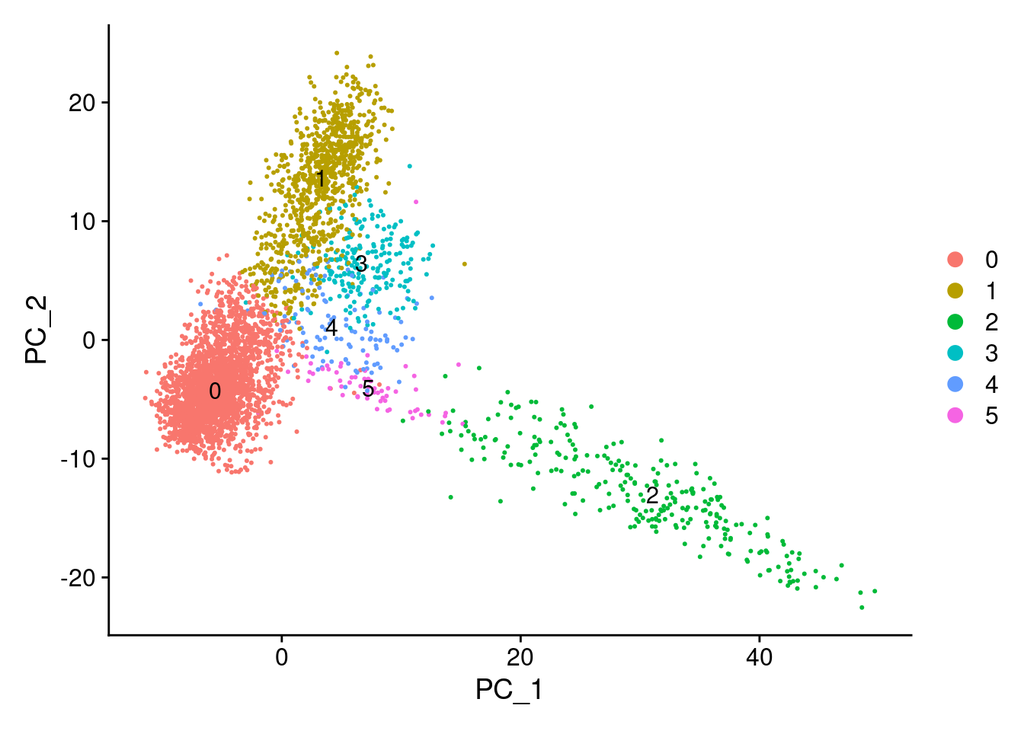

```r
DimPlot(
  seurat.obj.filtered ,
  dims = c(1, 2),
  reduction = "pca",
  label = TRUE
)
```

### t-Distributed Stochastic Neighbor Embedding dimensional reduction

Afterwards I compute the *t-distributed stochastic neighbor embedding* (t-SNE) parameters. t-SNE is a dimensional reduction method that discriminates clusters really well. First, the probability proportional to similarity is calculated for each pair. For data point $x_{j}$ to data point $x_{i}$ this is the conditional probability, $p_{j|i}}$, that $x_{i}$ would pick $x_{j}$ as its neighbor if neighbors were picked in proportion to their probability density under a student t centered at $x_{i}$. Then a distribution in the lower space is computed iteratively (through gradient descent) to minimize the Kullback–Leibler divergence between it and the full dimensional distribution.

For our application, we will use Seurat’s `RunTSNE`. It does not work directly on the genes as dimensions as t-SNE struggles with too many dimensions. It uses the principal components computed above, since PC are good at separating signal from noise. We need to choose a parameter named perplexity that roughly sets how much impact closer points have over points further apart.

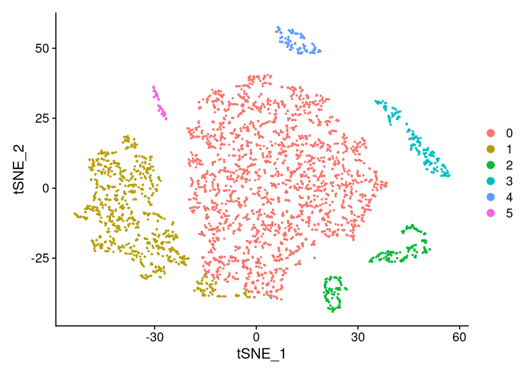

```r
seurat.obj.filtered <-
  RunTSNE(
    seurat.obj.filtered,
    dims.use = 1:n.pcs,
    seed.use = 42,
    perplexity = 15,
    dim.embed = 2
  )
TSNEPlot(seurat.obj.filtered)
```

## Differential expression

The differential expression analysis can be performed with `FindAllMarkers`. This function provides a table detailing the marker genes of each cluster. Including its id, the cluster in which it is differentially expressed, the difference in expression and the metric used to find the markers. The metric used is the area under the curve (AUC). To compute it, the function builds a classifier for each combination of gene and cluster, with that gene as the only classifier and a with the cluster and the rest of cells as the two classes. To evaluate the classifier, `FindAllMarkers` returns the area under the receiver operating characteristic (ROC), which is the true positive rate against the false positive rate. Essentially measures how well the gene discriminates between the cells of cluster and the rest of cells. An AUC value of 1 means that expression values for this gene alone can perfectly classify the two groupings: *Each of the cells in the evaluated cluster exhibit a higher level of the evaluated gene than in the cells of the rest of clusters*. An AUC value of 0 also means there is perfect classification, which means that lesser expression predicts that the cell belong to the cluster. However, we will only evaluate genes that are more expressed than the average in the cluster, as we want to find marker genes and not build a classifier.

```r
markers <-
  FindAllMarkers(
    object = seurat.obj.filtered,
    test.use = "roc",
    only.pos = TRUE,
    min.pct = 0.1,
    return.thresh = 0.02
  )
rownames(markers) <- c()
```

```r
externalid2description <- read.csv(extid2descriptionpath)
anotated_table <- data.frame()
for (i in unique(markers$cluster)) {
  markers %>%
    dplyr::select(gene, cluster, myAUC, avg_log2FC) %>%
    filter(cluster == i) %>%
    top_n(10, myAUC) %>%
    left_join(externalid2description, by = "gene") -> cluster
  anotated_table <- rbind(anotated_table, cluster)
}

knitr::kable(anotated_table)
```

| gene | cluster | myAUC | avg_log2FC | description |
| --- | --- | --- | --- | --- |
| Cytl1 | 0 | 0.964 | 5.2611607 | cytokine-like 1 [Source:MGI Symbol;Acc:MGI:2684993] |
| Chad | 0 | 0.944 | 3.6250483 | chondroadherin [Source:MGI Symbol;Acc:MGI:1096866] |
| Mia1 | 0 | 0.928 | 3.5525967 | NA |
| Col11a1 | 0 | 0.928 | 3.5576514 | collagen, type XI, alpha 1 [Source:MGI Symbol;Acc:MGI:88446] |
| Fn1 | 0 | 0.926 | 3.2337797 | fibronectin 1 [Source:MGI Symbol;Acc:MGI:95566] |
| Wif1 | 0 | 0.917 | 2.7293879 | Wnt inhibitory factor 1 [Source:MGI Symbol;Acc:MGI:1344332] |
| 3110079O15Rik | 0 | 0.917 | 4.5504765 | NA |
| Cpe | 0 | 0.897 | 2.3468494 | carboxypeptidase E [Source:MGI Symbol;Acc:MGI:101932] |
| Acan | 0 | 0.897 | 3.4190567 | aggrecan [Source:MGI Symbol;Acc:MGI:99602] |
| Col9a2 | 0 | 0.897 | 3.2899413 | collagen, type IX, alpha 2 [Source:MGI Symbol;Acc:MGI:88466] |
| Col1a1 | 1 | 0.963 | 3.4962261 | collagen, type I, alpha 1 [Source:MGI Symbol;Acc:MGI:88467] |
| Col3a1 | 1 | 0.950 | 3.6416296 | collagen, type III, alpha 1 [Source:MGI Symbol;Acc:MGI:88453] |
| Gsn | 1 | 0.943 | 3.0656133 | gelsolin [Source:MGI Symbol;Acc:MGI:95851] |
| Serpinf1 | 1 | 0.923 | 2.8274979 | serine (or cysteine) peptidase inhibitor, clade F, member 1 [Source:MGI Symbol;Acc:MGI:108080] |
| Dpt | 1 | 0.919 | 3.8476738 | dermatopontin [Source:MGI Symbol;Acc:MGI:1928392] |
| Igfbp4 | 1 | 0.911 | 3.0976090 | insulin-like growth factor binding protein 4 [Source:MGI Symbol;Acc:MGI:96439] |
| Lgals1 | 1 | 0.902 | 2.0840532 | lectin, galactose binding, soluble 1 [Source:MGI Symbol;Acc:MGI:96777] |
| Serping1 | 1 | 0.898 | 3.2377238 | serine (or cysteine) peptidase inhibitor, clade G, member 1 [Source:MGI Symbol;Acc:MGI:894696] |
| Mfap5 | 1 | 0.888 | 3.1431956 | microfibrillar associated protein 5 [Source:MGI Symbol;Acc:MGI:1354387] |
| Col1a2 | 1 | 0.886 | 1.9017698 | collagen, type I, alpha 2 [Source:MGI Symbol;Acc:MGI:88468] |
| Tyrobp | 2 | 0.989 | 4.4056169 | TYRO protein tyrosine kinase binding protein [Source:MGI Symbol;Acc:MGI:1277211] |
| Tmsb4x | 2 | 0.987 | 3.1793403 | thymosin, beta 4, X chromosome [Source:MGI Symbol;Acc:MGI:99510] |
| Fcer1g | 2 | 0.980 | 4.3026162 | Fc receptor, IgE, high affinity I, gamma polypeptide [Source:MGI Symbol;Acc:MGI:95496] |
| Cd74 | 2 | 0.971 | 7.3606976 | CD74 antigen (invariant polypeptide of major histocompatibility complex, class II antigen-associated) [Source:MGI Symbol;Acc:MGI:96534] |
| Ctss | 2 | 0.968 | 3.7339023 | cathepsin S [Source:MGI Symbol;Acc:MGI:107341] |
| Lyz2 | 2 | 0.962 | 4.9161374 | lysozyme 2 [Source:MGI Symbol;Acc:MGI:96897] |
| H2-Aa | 2 | 0.951 | 6.2368412 | histocompatibility 2, class II antigen A, alpha [Source:MGI Symbol;Acc:MGI:95895] |
| Cyba | 2 | 0.946 | 2.5144070 | cytochrome b-245, alpha polypeptide [Source:MGI Symbol;Acc:MGI:1316658] |
| H2-Ab1 | 2 | 0.945 | 6.0643855 | histocompatibility 2, class II antigen A, beta 1 [Source:MGI Symbol;Acc:MGI:103070] |
| H2-Eb1 | 2 | 0.937 | 6.0073361 | histocompatibility 2, class II antigen E beta [Source:MGI Symbol;Acc:MGI:95901] |
| Ifitm3 | 3 | 0.921 | 2.4146803 | interferon induced transmembrane protein 3 [Source:MGI Symbol;Acc:MGI:1913391] |
| Gng11 | 3 | 0.882 | 2.9813035 | guanine nucleotide binding protein (G protein), gamma 11 [Source:MGI Symbol;Acc:MGI:1913316] |
| Tmsb4x | 3 | 0.836 | 1.0705910 | thymosin, beta 4, X chromosome [Source:MGI Symbol;Acc:MGI:99510] |
| Calm1 | 3 | 0.833 | 1.5100062 | calmodulin 1 [Source:MGI Symbol;Acc:MGI:88251] |
| Egfl7 | 3 | 0.806 | 2.8501872 | EGF-like domain 7 [Source:MGI Symbol;Acc:MGI:2449923] |
| Tm4sf1 | 3 | 0.803 | 2.2281649 | transmembrane 4 superfamily member 1 [Source:MGI Symbol;Acc:MGI:104678] |
| Ppia | 3 | 0.799 | 0.9963841 | peptidylprolyl isomerase A [Source:MGI Symbol;Acc:MGI:97749] |
| Vim | 3 | 0.791 | 1.3067713 | vimentin [Source:MGI Symbol;Acc:MGI:98932] |
| Tmsb10 | 3 | 0.789 | 1.3223804 | thymosin, beta 10 [Source:MGI Symbol;Acc:MGI:109146] |
| Cdh5 | 3 | 0.788 | 2.6199163 | cadherin 5 [Source:MGI Symbol;Acc:MGI:105057] |
| Ecscr | 3 | 0.788 | 2.6242147 | endothelial cell surface expressed chemotaxis and apoptosis regulator [Source:MGI Symbol;Acc:MGI:1915795] |
| Pecam1 | 3 | 0.788 | 2.9904225 | platelet/endothelial cell adhesion molecule 1 [Source:MGI Symbol;Acc:MGI:97537] |
| Wfdc2 | 4 | 0.983 | 5.8120195 | WAP four-disulfide core domain 2 [Source:MGI Symbol;Acc:MGI:1914951] |
| Cbr2 | 4 | 0.963 | 5.0868173 | carbonyl reductase 2 [Source:MGI Symbol;Acc:MGI:107200] |
| Gsto1 | 4 | 0.944 | 4.9877424 | glutathione S-transferase omega 1 [Source:MGI Symbol;Acc:MGI:1342273] |
| Cyp2f2 | 4 | 0.941 | 5.1113286 | cytochrome P450, family 2, subfamily f, polypeptide 2 [Source:MGI Symbol;Acc:MGI:88608] |
| Spint2 | 4 | 0.939 | 3.2623210 | serine protease inhibitor, Kunitz type 2 [Source:MGI Symbol;Acc:MGI:1338031] |
| Krt19 | 4 | 0.938 | 4.1418307 | keratin 19 [Source:MGI Symbol;Acc:MGI:96693] |
| Krt18 | 4 | 0.917 | 3.5100196 | keratin 18 [Source:MGI Symbol;Acc:MGI:96692] |
| Selenbp1 | 4 | 0.903 | 3.5174293 | selenium binding protein 1 [Source:MGI Symbol;Acc:MGI:96825] |
| Ifitm1 | 4 | 0.902 | 3.8114679 | interferon induced transmembrane protein 1 [Source:MGI Symbol;Acc:MGI:1915963] |
| Krt15 | 4 | 0.902 | 5.2791794 | keratin 15 [Source:MGI Symbol;Acc:MGI:96689] |
| Uba52 | 5 | 0.969 | 1.3988865 | ubiquitin A-52 residue ribosomal protein fusion product 1 [Source:MGI Symbol;Acc:MGI:98887] |
| Cd52 | 5 | 0.968 | 3.4462808 | CD52 antigen [Source:MGI Symbol;Acc:MGI:1346088] |
| Tmsb10 | 5 | 0.958 | 2.6527489 | thymosin, beta 10 [Source:MGI Symbol;Acc:MGI:109146] |
| Srgn | 5 | 0.947 | 2.7866871 | serglycin [Source:MGI Symbol;Acc:MGI:97756] |
| Rps15a | 5 | 0.946 | 1.2371195 | ribosomal protein S15A [Source:MGI Symbol;Acc:MGI:2389091] |
| Rpl13a | 5 | 0.944 | 1.0079430 | ribosomal protein L13A [Source:MGI Symbol;Acc:MGI:1351455] |
| H2-D1 | 5 | 0.943 | 2.0718480 | histocompatibility 2, D region locus 1 [Source:MGI Symbol;Acc:MGI:95896] |
| Fau | 5 | 0.939 | 1.2492298 | Finkel-Biskis-Reilly murine sarcoma virus (FBR-MuSV) ubiquitously expressed (fox derived) [Source:MGI Symbol;Acc:MGI:102547] |
| Rps24 | 5 | 0.937 | 1.0180039 | ribosomal protein S24 [Source:MGI Symbol;Acc:MGI:98147] |
| Vps37b | 5 | 0.930 | 2.9208248 | vacuolar protein sorting 37B [Source:MGI Symbol;Acc:MGI:1916724] |
| H2-K1 | 5 | 0.930 | 2.8131123 | histocompatibility 2, K1, K region [Source:MGI Symbol;Acc:MGI:95904] |

## Save files for comparisons

```r
anotated_table <- data.frame()
for (i in unique(markers$cluster)) {
  markers %>%
    dplyr::select(gene, cluster, myAUC, avg_log2FC) %>%
    filter(cluster == i) %>%
    top_n(10, myAUC) %>%
    left_join(externalid2description, by = "gene") -> cluster
  anotated_table <- rbind(anotated_table, cluster)
}
write.csv(anotated_table,
          paste(output_path, dataset, "anotatedTable.csv", sep = ""))
```

Lastly, I want to compare directly how many cells are in the same cluster both from Tabula Muris data and from our data. For that, I save a .csv with the cluster of each barcode.

```r
idents_TM <- as.data.frame(seurat.obj.filtered$cluster.ids)
idents_TM <- as.data.frame(cbind(rownames(idents_TM),idents_TM$`seurat.obj.filtered$cluster.ids`))
names(idents_TM)=c("CellBarcodes", "Cluster")
idents_TM[,1] <- substring(idents_TM[,1],11)
write.csv(idents_TM, paste(output_path, dataset, "idents.csv",sep = ""), row.names = F)
```